# Who’s Watching? Fast Food Ads and YouTube Viewers

## Purpose

The focus of my data collection was to see how many fast food advertisements were shown when watching YouTube videos in one sitting. I wanted to see how often fast food advertisements were shown and which fast food companies were most advertised during YouTube videos. I also had a look at whether or not people bought from the advertisements they were seeing in order to see whether or not people were actually being influenced by what was being shown to them. After all, advertisements are used to get more business!

## Popularity of Advertisements Seen on YouTube

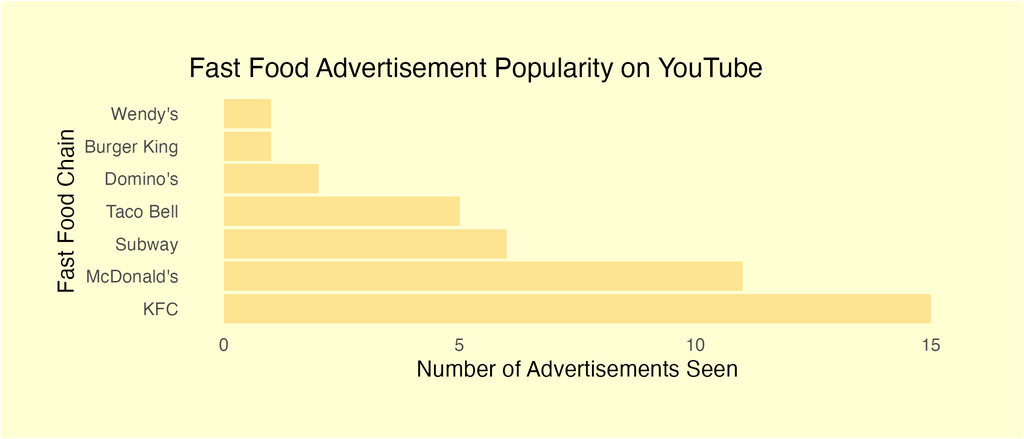

Graph showing how many times different fast food chains were seen advertising on YouTube

We see that KFC and McDonald’s advertisements are seen quite often while watching YouTube videos.

## Median Counts

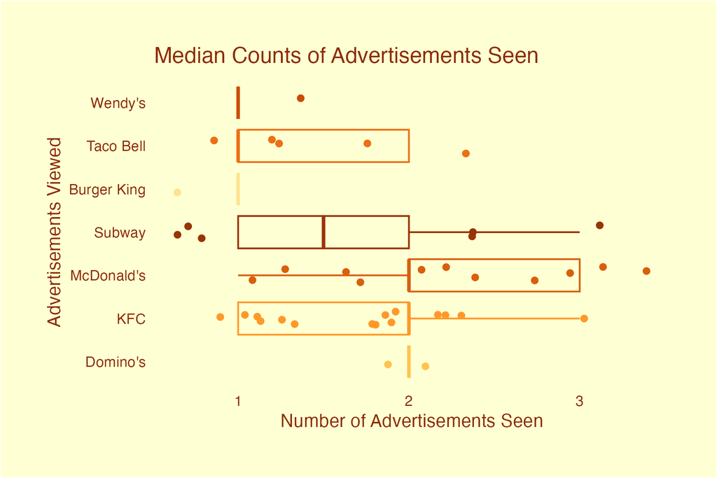

Graph showing median counts of fast food advertisements seen on YouTube

Data is very scattered meaning people were seeing a different number of ads.

## Who Actually Bought the Fast Food?

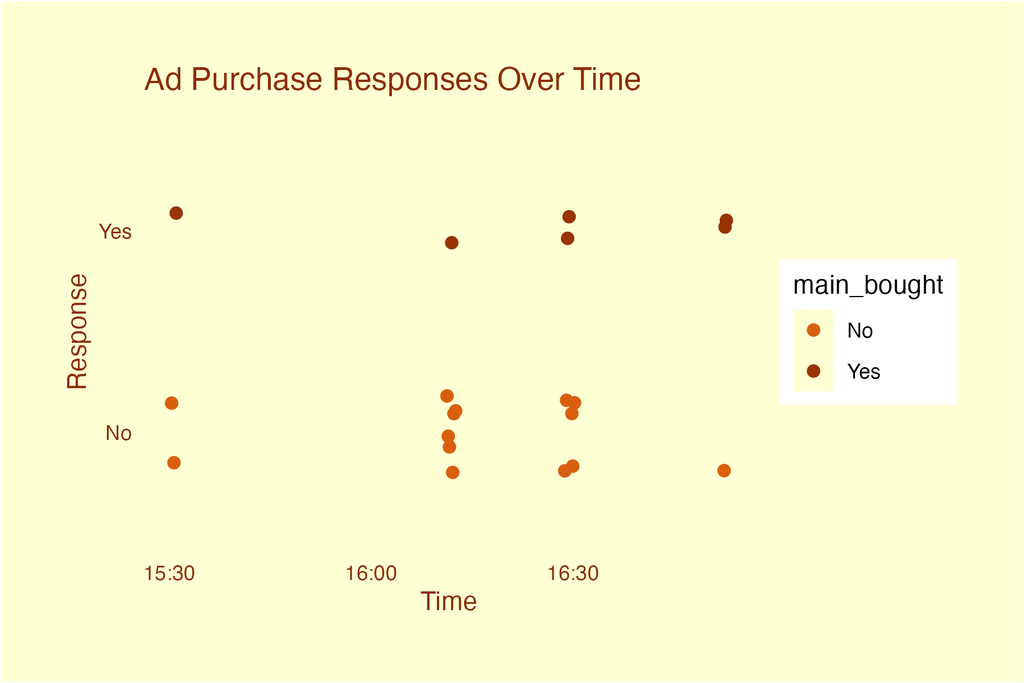

Graph showing when people bought the fast food if they did or didn’t

## Summary

Overall, we see that many people aren’t affected by the advertisements they see in that they don’t go out of their way to purchase what they have seen after they see it. Although, there is a small amount that are influences by the advertisements they see.